# Anàlisis Descriptiu de dades

## Visualitzacions

### Histogrames

```r
plot_histogram <- function(col, binwidth = 1, fill_color = "#ADD8E6") {
  ggplot(data, aes_string(x = col)) +
    geom_histogram(binwidth = binwidth, fill = fill_color, color = "Black") +
    theme_minimal()  # Remover ggtitle elimina los títulos
}

numeric_cols <- data %>% select_if(is.numeric) %>% colnames()
print(numeric_cols)
```

```
## [1] "Insulin.Levels"       "Age"                  "BMI"                  "Blood.Pressure"       "Cholesterol.Levels"   "Waist.Circumference"
## [7] "Blood.Glucose.Levels" "Pancreatic.Health"    "Birth.Weight"
```

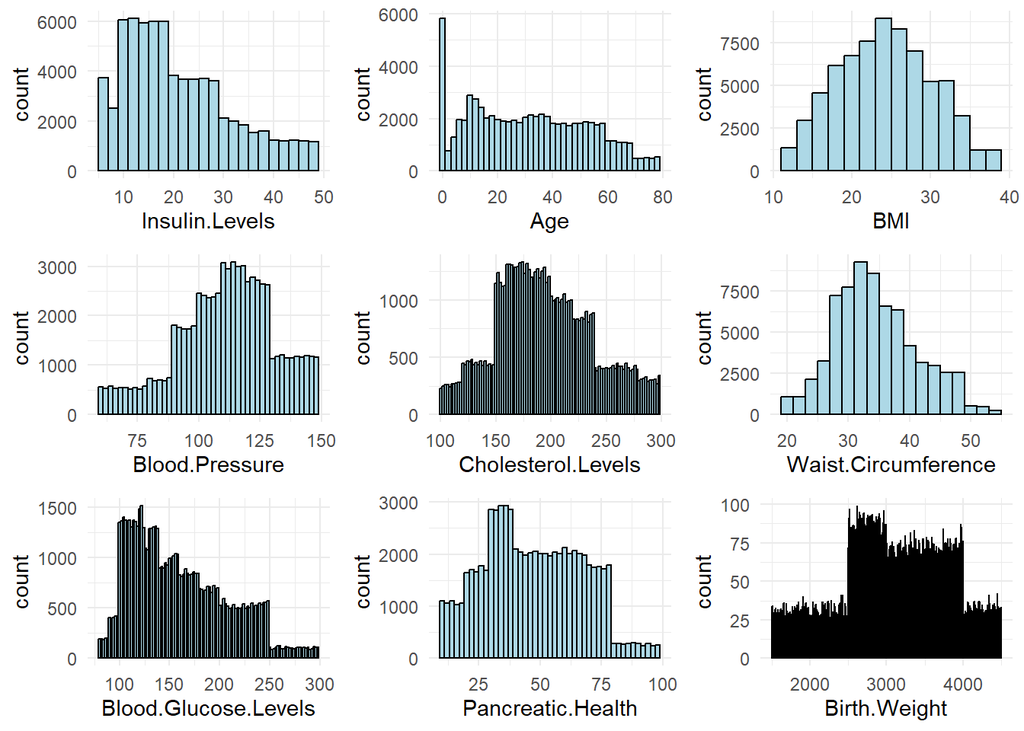

```r
plots <- lapply(numeric_cols, function(col) {
  plot_histogram(col, binwidth = 2, fill_color = "#ADD8E6")
})

grid.arrange(grobs = plots, ncol = 3)
```

### Boxplots

```r
numeric_cols <- data %>% select_if(is.numeric) %>% colnames()
print(numeric_cols)
```

```
## [1] "Insulin.Levels"       "Age"                  "BMI"                  "Blood.Pressure"       "Cholesterol.Levels"   "Waist.Circumference"
## [7] "Blood.Glucose.Levels" "Pancreatic.Health"    "Birth.Weight"
```

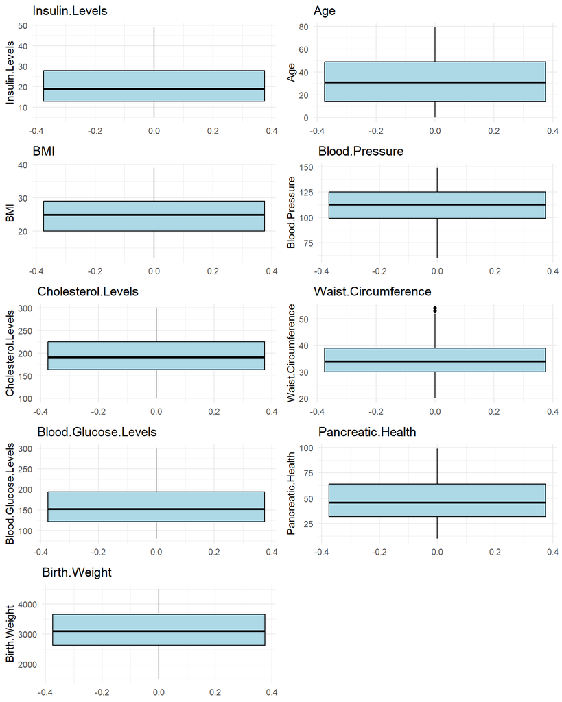

```r
plot_boxplot <- function(col, title = NULL, fill_color = "#ADD8E6") {
  ggplot(data, aes_string(y = col)) +
    geom_boxplot(fill = fill_color, color = "black") +
    scale_fill_brewer(palette="Pastel1") +
    theme_minimal() +
    ggtitle(ifelse(is.null(title), paste(col), title))
}

boxplots <- map(numeric_cols, ~plot_boxplot(.x, fill_color = "#ADD8E6"))

grid.arrange(grobs = boxplots, ncol = 2)
```

En general no s’observen practicament outliers notables.

### Barplots per a Variables Categòriques

```r
library(dplyr)

categorical_cols <- data %>% select_if(is.character) %>% colnames()
print(categorical_cols)
```

```
##  [1] "Target"                        "Genetic.Markers"               "Autoantibodies"                "Family.History"
##  [5] "Environmental.Factors"         "Physical.Activity"             "Dietary.Habits"                "Ethnicity"
##  [9] "Socioeconomic.Factors"         "Smoking.Status"                "Alcohol.Consumption"           "History.of.PCOS"
## [13] "Previous.Gestational.Diabetes" "Liver.Function.Tests"          "Urine.Test"                    "Early.Onset.Symptoms"
```

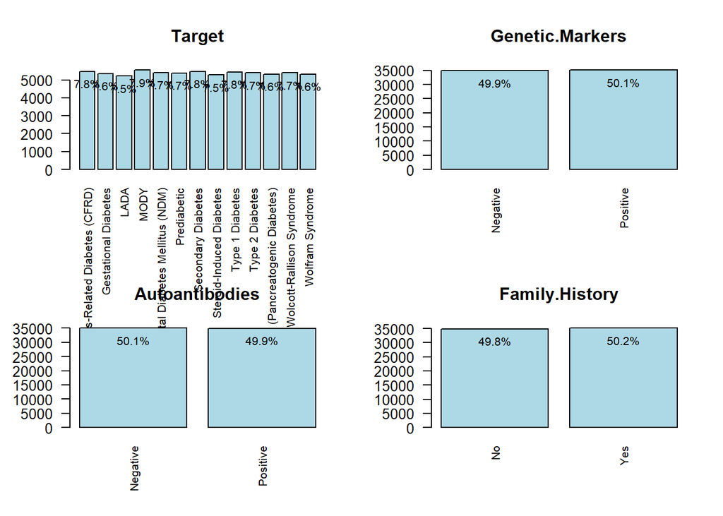

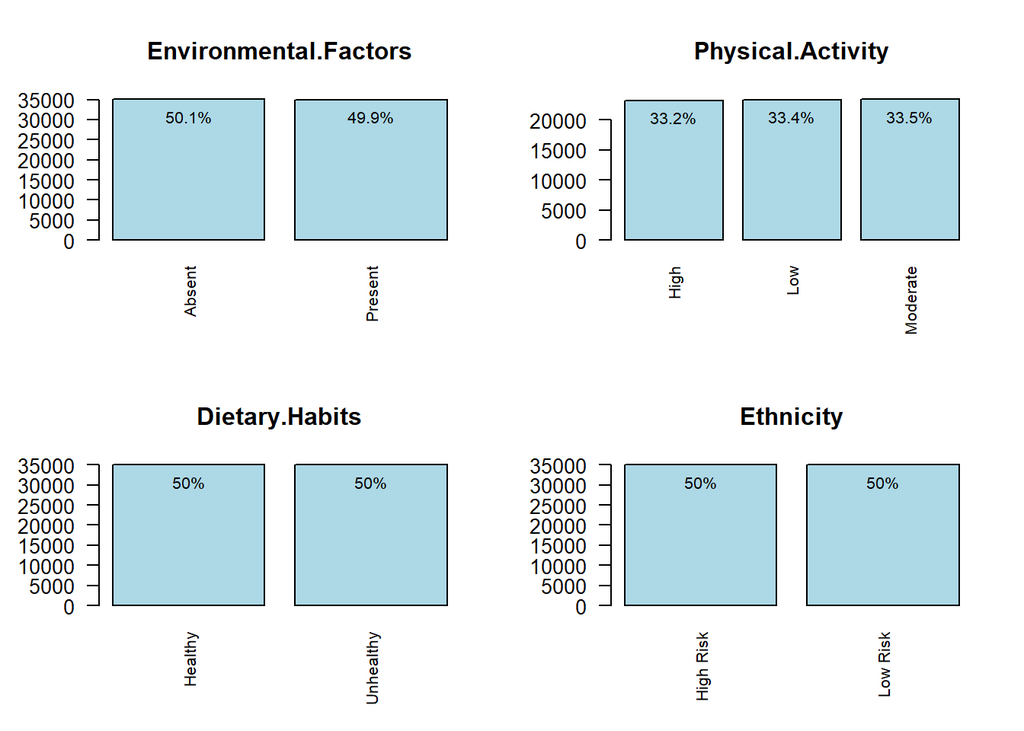

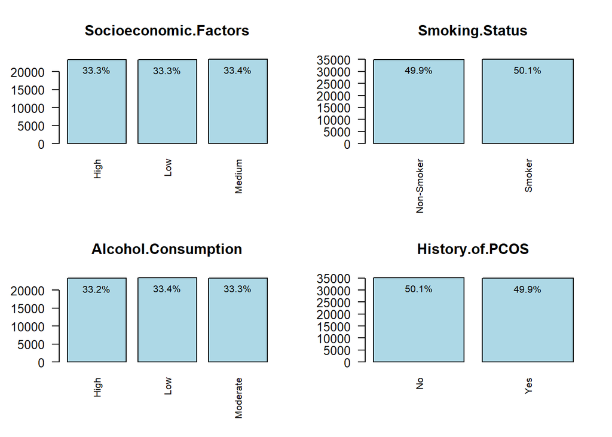

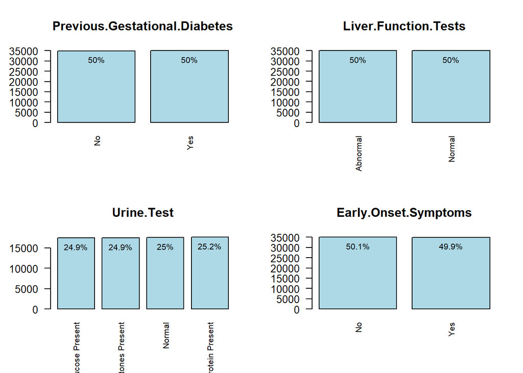

```r
plot_barplot_base <- function(data, col) {
  counts <- table(data[[col]])
  total <- sum(counts)
  bar_positions <- barplot(counts,
                           main = paste(col),
                           col = "#ADD8E6",
                           las = 2,
                           cex.names = 0.8)

  text(bar_positions, counts, labels = counts, pos = 3, cex = 0.8)

  percentages <- round((counts / total) * 100, 1)
  text(bar_positions, counts, labels = paste0(percentages, "%"), pos = 1, cex = 0.8, col = "black")
}

par(mfrow = c(2, 2)) # Ajusta según sea necesario

for (col in categorical_cols) {
  plot_barplot_base(data, col)
}
```

```r
par(mfrow = c(1, 1))
```

Pel que fa als barplots, es pot observar que d’un total de 16 variables categòriques mostrades n’hi ha un total d’11 que es mostren binàries, i totes i cadascuna mostren un equilibri gairebé igual entre els valors binaris.

Per tant, totes les classes estan proporcionalment ben representades al dataset.

# Anàlisis Bivariant

## Anàlisi Categòric i numèric

```r
numeric_vars <- data %>% select_if(is.numeric)
categorical_vars <- data %>% select_if(is.character)

cat_names <- colnames(categorical_vars)
chi_squared_results <- list()

for (i in 1:(ncol(categorical_vars)-1)) {
  for (j in (i+1):ncol(categorical_vars)) {
    table <- table(categorical_vars[[i]], categorical_vars[[j]])
    chi_test <- chisq.test(table)
    chi_squared_results[[paste(cat_names[i], "vs", cat_names[j], sep = " ")]] <- chi_test
  }
}

compact_results <- data.frame(
  Variables = character(),
  P_Value = numeric(),
  Significance = character(),
  stringsAsFactors = FALSE
)

for (result in names(chi_squared_results)) {
  p_value <- chi_squared_results[[result]]$p.value
  significance <- ifelse(p_value < 0.05, "Significant", "Not Significant")
  if (significance == "Significant") {
    compact_results <- rbind(compact_results, data.frame(
      Variables = result,
      P_Value = p_value,
      Significance = significance
    ))
  }
}

print(compact_results)
```

```
##                                     Variables     P_Value Significance
## 1                   Target vs Genetic.Markers 0.005307676  Significant
## 2      Autoantibodies vs Early.Onset.Symptoms 0.044271014  Significant
## 3     Environmental.Factors vs Smoking.Status 0.026311386  Significant
## 4 Previous.Gestational.Diabetes vs Urine.Test 0.008448902  Significant
```

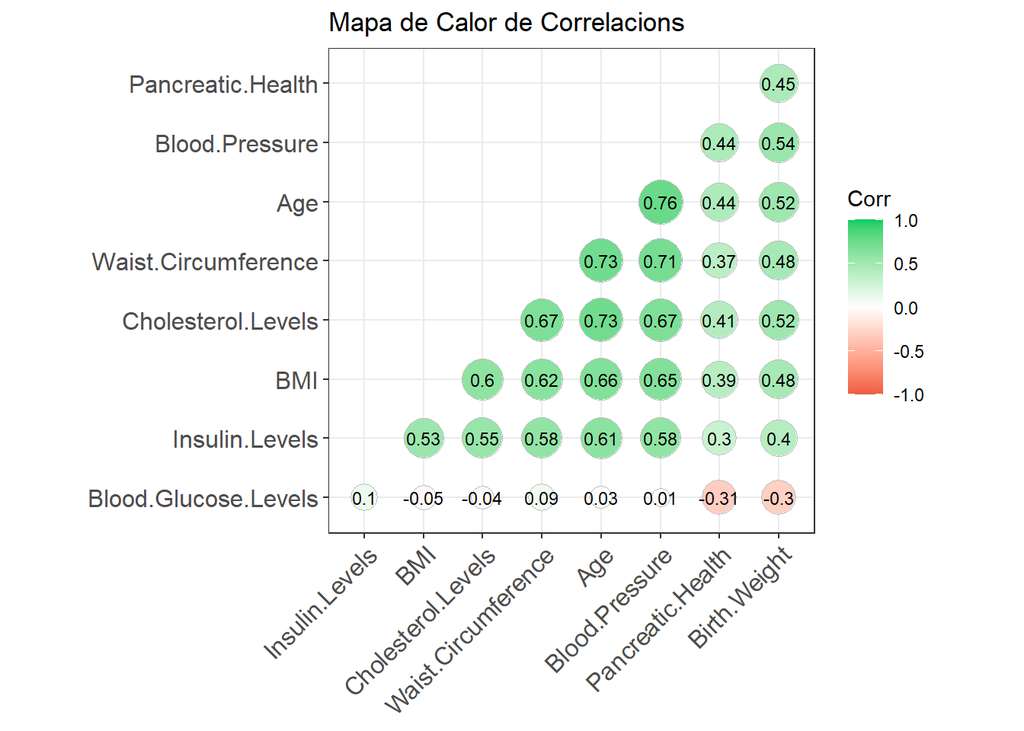

```r
# Heatmap
cor_matrix <- cor(numeric_vars)
ggcorrplot(cor_matrix,
           hc.order = TRUE,
           type = "lower",
           lab = TRUE,
           lab_size = 3,
           tl.cex = 1.2,
           method = "circle",
           colors = c("tomato2", "white", "springgreen3"),
           title = "Mapa de Calor de Correlacions",
           ggtheme = theme_bw()) +
  theme(axis.text.x = element_text(angle = 45, hjust = 1, size = 12),
        axis.text.y = element_text(size = 12))
```

Els test de chi-quadrat mostren que d’entre totes les variables categòriques hi ha 4 combinacions que sí que semblen tenir un patró en comú, cosa que sembla indicar una baixa associació en general entre les variables categòriques:

```
- Target vs Genetic.Markers con **
- Autoantibodies vs Early.Onset.Symptoms *
- Environmental.Factors vs Smoking.Status *
- Previous.Gestational.Diabetes vs Urine.Test **
```

Pel que fa al mapa de calor mostren en general correlacions moderades, excloent les dues variables amb menor correlació general (Pancreatic.Health i Birth.Weight) les variables que mostren amb la resta una millor correlació són Age, Waist.Circumference, Cholesterol.Levels i BMI i uns 5 punts per sota de correlació positiva Insulin.Levels. Cal destacar la baixíssima correlació de Blood.Glucose.Levels, la qual arriba a tenir fins i tot una correlació negativa amb Pancreatic.Health i Birth.weight.